# spm fMRI 初学者笔记 #2

程诚柏然

2024-06-07

# 导言

这篇随笔针对许多有兴趣于fMRI但是受限于平台或机会对相关知识操作并不是那么accessible的心理学同窗们，包括我自己在写这篇东西的时候也是边学边写，这里也感谢深圳大学何振宏教授课题组能够让我有接触核磁数据处理的机会。fMRI的预处理包括了许多步骤，这些步骤可以在目录导航看到，此处不多赘述。通俗来说，这玩意有两种类型的图片或者影像：功能像和结构像。有普通心理学基础的各位都对fMRI有印象：让被试做任务或者干个什么事情，他脑子某个区域就激活，而这个激活的图像，就是由功能像图片告诉我们；可是这个激活准确而言是在哪里或者说哪个结构的位置，这就需要结构像为我们提供信息。而预处理打个不准确的比方，就好像用ai修复清代老照片（这个表述有些夸张），让我们本来的图像更加清晰，分析起来更加准确。就像很多新生初次学习SPSS一样，SPSS课程进度往往比心理统计快，所以容易造成初学者不知道自己操作的意义是什么，本篇随笔就是针对背景薄弱的同窗们学习SPM操作时，能够有个东西提示我们每个操作最基本的意义是什么，甚至每个必要参数的基本的意义是什么。

本人知道，在目前信息发达的时代，很多人写的东西要比这篇随笔更强，但是在我学习有关概念的时候，我发现很多博客或者视频只是教授各位如何去操作，而很少涉及为什么要这样操作。我相信翻开这篇随笔的各位应该不满足于自己不知其所以然的样子。因此我决定将网络或各个来源的碎片化知识在这里进行一个粗糙的整合，若是能够发挥一丝作用，本人实属荣幸。本版本仅先针对事件相关设计的核磁处理（event-related design）其他类型取决于本人以后有没有学上

# 4 头动校正 Realignment

## 操作意义

这个操作就很好理解，而且还能学会三个地道表达的新单词：yaw、row、pitch，很6。因为fMRI扫描一次脑就需要几秒的时间，而单单扫描几次全脑根本达不到科学统计的最低样本要求，因而这就造成了fMRI实验过程很漫长，相比于行为实验一个trial的时间可能就几秒，fMRI的一个trial可能奔着十秒以上去了。同样的试次，行为实验可能被试已经事了拂衣去，fMRI的被试还可能在机子里煎熬，并且有些机构还得换衣服。这就形成了一个问题：长时间保持颈椎一动不动是一件痛苦的事情，这也是本人的鞠老师说过这玩意大小伙子来当被试正好的原因。因而为了图像质量，我们不得不抛弃任意维度头动超过3cm的被试，在此基础上对剩下的被试进行位置的矫正。

### 与AC-PC对齐的差异

不过说到头动，很多人想必会和我一样有个困惑，这个步骤的意义听起来和前面的AC-PC对齐有一些相似之处，一下子有些混淆。其实两个步骤之间仍然是存在着一些的区别的：

|  | 头动校正 | AC-PC对齐 |
| --- | --- | --- |
| 操作对象 | 主要是功能像 | 主要是T1结构像 |
| 操作意义 | 将时间序列中多个由于头动发生位移的功能像按其内部参考点对齐 | 将单个T1结构像与外部某“模板头”对齐 |
| 操作效果 | 使得时间序列中的每个体素位置保持一致 | 将个体的大脑图像对齐到一个标准的空间，以便于比较和定位 |
| 操作方式 | 可使用btach批处理 | 手动one by one或半自动 |

这时候需要再补充一句，头动校正就好像是一个小学生列队内部一二一把动作统一；AC-PC对齐则是结构像对着电视里模特走秀学走路。

### 补课指路牌

虽然头动校正背后的意义听起来很简单，但是在实际中，其实有挺多参数还是需要再话时间理解的，比如在[刘梦醒博士的此视频讲解](https://www.bilibili.com/video/BV1nb4y1R7k1)中便与何教授不同，单个nii可能包含了多个**frame**、或者几个**Session**的文件可以在一起处理等。你看，上面我说的俩新名词就是之前在《spm fMRI 初学者笔记 #1》里转格式那一章的笔记内容（建议各位回去翻一下）。我们在进行指定路径并选中文件的时候便需要考虑到这些因素的变化。

## 实务操作

[figure not shown]

图4-1不同的校正选项

### 个人对参数的理解

在SPM12中，头动校正功能就在界面的左上排头第一个的位置（如图4-1），这里展开之后我们可以看到不同的功能选择，它们的功能差异可以参考newbing提供的回答：

> 想象一下，你有一堆拼图块，你需要把它们拼成一幅完整的画面。这些拼图块就像你的fMRI图像，而拼成的画面就是你想要分析的大脑活动的完整视图。

> 如果你只是想要检查每个拼图块是否有瑕疵（比如头动），你可能会选择**Estimate**。这就像是检查每个拼图块，确保它们都是完好无损的，但你还没有开始拼图。

> 如果你已经知道哪些拼图块有问题，并且你想要修复它们，那么你会选择**Reslice**。这就像是用胶水把破损的拼图块修复好，让它们可以完美地拼在一起。

> 如果你既想检查拼图块，又想修复它们，那么你会选择**Estimate & Reslice**。这就是最常见的情况，你一边检查拼图块，一边修复它们，确保最后能拼出完整的画面。

> 最后，如果你的拼图块因为某些原因（比如磁场不均匀性）变形了，你需要特别的工具来修正它们，这时你会选择**Realign & Unwrap**。这就像是使用一个特殊的工具来把变形的拼图块恢复原状，以便它们能够准确地拼在一起。

相信以上的说明是足够通俗的，在这个基础上，我们可以再进行比较正式的说明补充。**Estimate**选项用于估计图像之间的运动参数。它不会创建新的校正后的图像，只会生成参数文件（见图4-2），这个ps后缀文件会被程序存在原始数据所在的文件夹，另外还会生成一个`rp_*.txt`文件也记录相关参数。在Estimate的结果基础上，我们可以首先通过头动幅度是否过大来判单该被试是不是可以剔除，这个标准是空间移动每个维度在3cm以内、不同层面头部转动不超过3 degree。

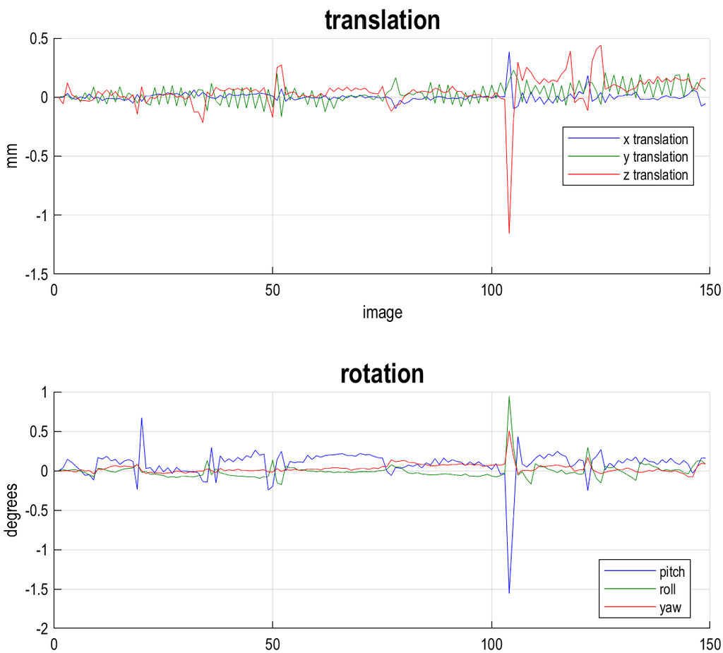

图4-2 Estimate所生成的头动参数文件

**Reslice**这个选项则用于根据之前估计的运动参数来调整图像，使其与参考图像对齐。这适用于当你已经有了运动参数并且想要创建校正后的图像。这里本人一开始觉得鸡肋，因为如果没有estimate的头动参数，Reslice就做不了，所以就很迷为什么这个reslice还单独成一个选项。但其实不然，这样设置确实给个程序灵活性。比如在一个大型的数据处理流程中的早期阶段我们已经估计了运动参数，这些运动参数可能使用于几个Session，然后在流程的后续步骤中，我们可能需要重新应用这些参数来校正其他类型的图像，或者对同一组图像进行不同的分析。这时，Reslice就派上用场了，因为它可以自动去寻找你之前估计好的参数文件`rp_*.txt`，而不必每次都重新运行Estimate步骤，节省时间和算力。

**Realign & Unwrap**则适用于我们同时需要校正头部运动和磁场不均匀造成的伪影。想要理解这个参数，我们则先需要理解**磁场不均匀校正**这个概念，这个步骤非常重要，因为如果磁场不均匀，那么同样的激活程度，A处磁场更强而B处磁场稍弱的情况下，图像上的某些部分可能会看起来比其他部分更亮或更暗，实际上强度一样的激活会看起来A处比B处更活跃。这会影响我们对大脑活动的解读。所以，磁场不均匀性校正帮助我们确保图像质量，让我们能够更准确地分析大脑功能。虽然这里选项上没有写，其实Realign & Unwrap包含了Estimate，也会首先计算头动参数，再自动依据`rp_*.txt`文件进行校正。同时，Realign & unwrap还需要我们提前进行**计算体素位移图（Calculate VDM）**，体素位移计算结果作为Realign & unwrap的运行参考数据，这个道理和数据与 Reslice需要头动参数差不多。

|  | Reslice | Realign & Unwrap |
| --- | --- | --- |
| 操作对象 | 单纯由于被试物理运动造成的图像位移 | 由于机器可能存在的磁场不均匀造成的图像扭曲、伪影 |
| 所需素材 | 被试头动参数 | 头动参数&体素位移图 |

**计算体素位移图（Calculate VDM）**是理论上我们进行Realign & Unwrap的必要条件。Calculate VDM是场图校正过程的一个重要步骤。体素位移图（VDM）是一种特殊的图像，它记录了由于磁场不均匀性导致的每个体素位置的变化。通俗地说，VDM就像是一张地图，上面标记了每个体素因为磁场问题而需要移动到的新位置。那么同理，我们要修正磁场不均，就需要按照这张图反向操作。